# CPLN 675 - Urban Growth Modeling, 2022

#### ROC Curve

The area under our model’s ROC curve is 0.9175 – suggesting that our model is high quality! But with the information from the Confusion Matrix & Graph, it is high quality at predicting the majority of our data – which is non-development. Lets get a map to truly understand the difficulties before I rip this model to shreds and get a B in this class.

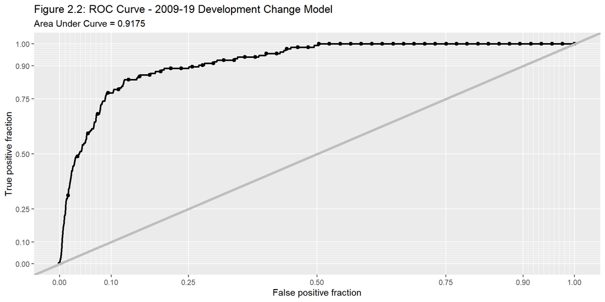

```r
#library(rROC)

library(plotROC)

ggplot() +
  geom_roc(
    data = focus.ROC,
    aes(d = labels, m = predictions),
    n.cuts = 50, labels = FALSE, colour = "#000000") +
  # geom_roc(
  #   data = test.predict,
  #   aes(d = as.numeric(test.predict$outcome), m = predict.2),
  #   n.cuts = 50, labels = FALSE, colour = "#FE9900") +
  style_roc(theme = theme_grey) +
  geom_abline(slope = 1, intercept = 0, size = 1.5, color = 'grey') +
  labs(
    title = "Figure 2.2: ROC Curve - 2009-19 Development Change Model",
    subtitle = glue("Area Under Curve = {AUC}")
    )
```

#### Confusion Map

The map secures the evidence that the model is over estimating developments. It appears that my model is considering open land too highly without regarding the political & legal constraints of a land trust or preserve. I believe that most predicted New Developments disappear when considering the many jurisdictonal land-use restraints. So numerous that I couldn’t find an accurate land use regulation dataset, *and I work at one of those jurisdictions in Contra Costa County (CC).*

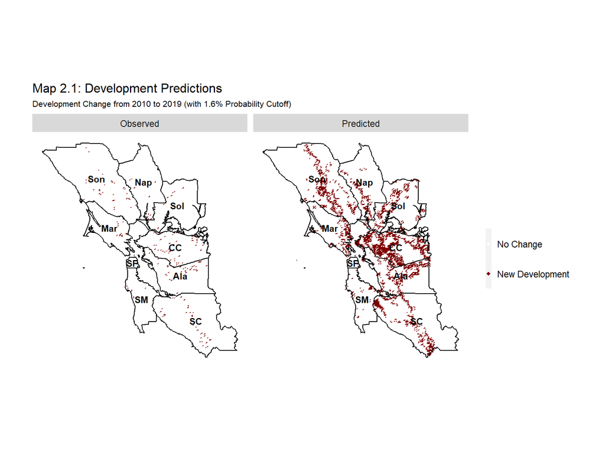

```r
sf.fish %>%
  dplyr::select(dev_ch.09_19, dev_ch.09_19.predict) %>%
  transmute(
    `Observed` = dev_ch.09_19,
    `Predicted` = dev_ch.09_19.predict
  ) %>%
  gather(Variable, Value, -geometry) %>%
  ggplot(
    data=.,
   aes(x=xyC(.data[['geometry']])[,1], y=xyC(.data[['geometry']])[,2],
       colour=Value %>% as.factor())
    ) +
    geom_point(shape=18) +
    facet_wrap(~Variable) +
    scale_colour_manual(values = c('#FFFFFF','#800000'), labels=c("No Change","New Development"),
                        name="") +
    geom_county() +
    geom_county_text() +
    labs(title="Map 2.1: Development Predictions", subtitle="Development Change from 2010 to 2019 (with 1.6% Probability Cutoff)") +
    mapTheme
```

Excuses aside, Map 2.2 highlights the results in a map. This map highlights how small the New Developments dataset is and how there is alot of fine tuning needed to understand Bay Area growth.

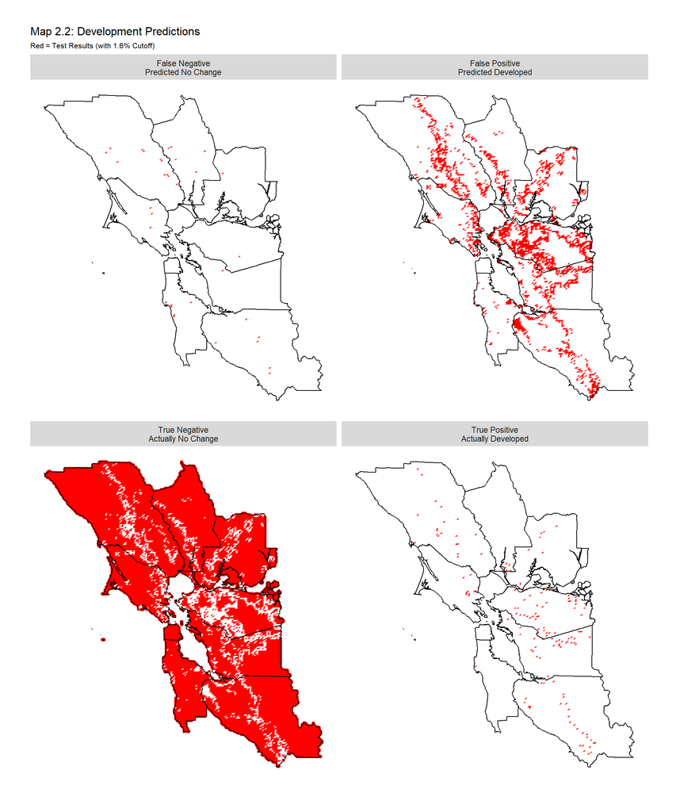

```r
ConfusionMatrix.metrics <-
  sf.fish %>%
    mutate(dev.True.Pos = ifelse(dev_ch.09_19  == 1 & dev_ch.09_19.predict == 1, 1,0),
           dev.True.Neg = ifelse(dev_ch.09_19  == 0 & dev_ch.09_19.predict == 0, 1,0),
           dev.False.Pos = ifelse(dev_ch.09_19  == 0 & dev_ch.09_19.predict == 1, 1,0),
           dev.False.Neg = ifelse(dev_ch.09_19  == 1 & dev_ch.09_19.predict == 0, 1,0)
           ) %>%
    dplyr::select(.,
                  c('dev.True.Pos', 'dev.True.Neg', 'dev.False.Pos', 'dev.False.Neg')) %>%
  transmute(
    `True Negative\nActually No Change` = dev.True.Neg,
    `False Positive\nPredicted Developed` = dev.False.Pos,
    `False Negative\nPredicted No Change` = dev.False.Neg,
    `True Positive\nActually Developed` = dev.True.Pos
  ) %>%
  gather(Variable, Value, -geometry)

ggplot(data=ConfusionMatrix.metrics) +
  geom_point(aes(x=xyC(ConfusionMatrix.metrics)[,1],
                 y=xyC(ConfusionMatrix.metrics)[,2], colour = as.factor(Value))) +
  facet_wrap(~Variable) +
  scale_colour_manual(values = c('#FFFFFF', '#FF0000'), labels=c("Correct","Incorrect"),
                       name="") +
  #geom_county_text() +
  geom_county() +
  labs(title="Map 2.2: Development Predictions",
       subtitle="Red = Test Results (with 1.6% Cutoff)") +
  mapTheme +
  theme(legend.position = "none")
```

# 3. Predicting Population

The next section is *supposed to* evaluate how a population projection can influence predicted developments. The population data is from Plan Bay Area 2040 [[link](http://projections.planbayarea.org/)]

## 3.1. 2030 Population

My strategy was to bring in 2030 populations for each county. Find out what percentage each cell accounted for the county’s 2019 population. Then multiply that percentage by the county’s 2030 projected population.

Figure 3.1 shows Plan Bay Area’s projections for the next 20 years. The counties that have higher density, higher growth, *and* higher amounts of open land – Alameda & Santa Clara – all suggest higher growth rates and totals. Just outside of that criteria is San Francisco – who is running out of immediately developable land. Contra Costa has open land and a strong suburban core – but has both preserves and (development) conservative city jurisdictions. The other counties have a ton of open land but a land use philosophy of an old curmudgeon. All of these counties are ones who shot down BART’s full-bay expansion in the 1960s so they can focus on highways and *very* exclusionary land use practices.

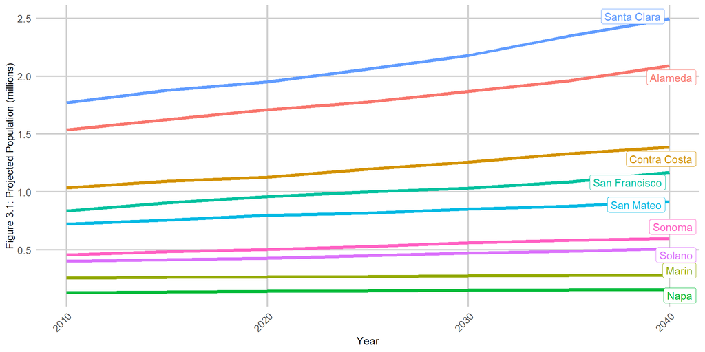

```r
path = paste(DIR, "data/sf_pop_data.xlsx", sep='/')
sf.pop_proj = read_excel(path)
col_names = c("County", "X2010", "X2015", "X2020", "X2025", "X2030", "X2035", "X2040")
colnames(sf.pop_proj) = col_names
sf.pop_proj.2030 = sf.pop_proj %>% dplyr::select(County, X2030)
sf.pop_proj.2030.tot = sf.pop_proj.2030$X2030 %>% sum()

sf.pop_proj %>%
  gather(variable, value, -County) %>%
  mutate(Year = sapply(variable, function(s) str_replace(s, 'X','')) %>%
           as.integer(),
         Population = value/1000000,
         label = if_else(Year == max(Year), as.character(County), NA_character_)
         ) %>%
  ggplot(., aes(x=Year, y=Population, group=County, color=County), color='lightgrey') +
    geom_line(lwd=1.5) +
    geom_label_repel(aes(label = label),
      nudge_x = 10,
      na.rm = TRUE) +
    ylab('Figure 3.1: Projected Population (millions)') +
    xlab('Year') +
    plotTheme +
  theme(legend.position = "none")
```

My method of divying up the 2030 population projection can be seen in Map 3.1. The first two population periods show more natural, uneven population loses and gains. The anti-development North Bay actually had population loses in the 2000-2019 period. The loses could also be exacerbated by the interpolation method of joining tracts to fishnets. Those areas also have low amounts of developed areas and populations. My suggested population growth of 2019 to 2030 appears to mostly show the entire county’s growth. Likely a result of my method of multiplying the 2019 percent share to the 2030 total.

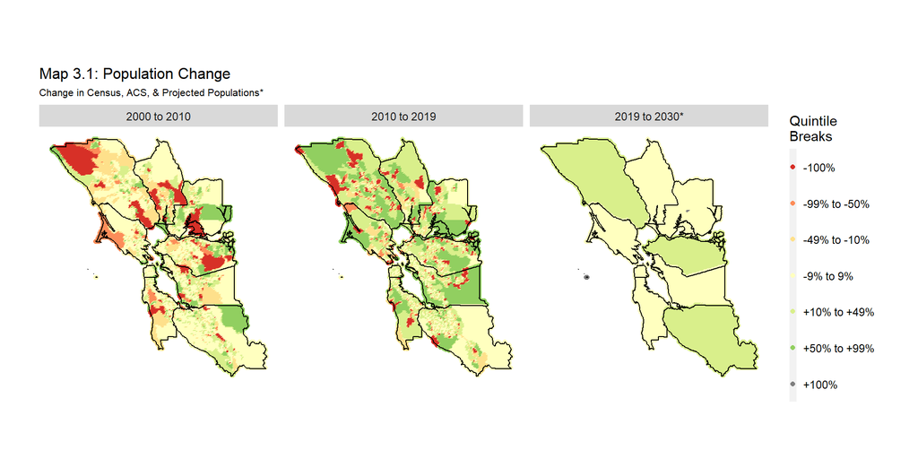

```r
sf.fish_pop = left_join(
    sf.fish,
    sf.pop_proj %>%
      mutate(id.county = County, pop.30.tot = X2030, pop.20.tot = X2020) %>%
      dplyr::select(id.county, pop.30.tot, pop.20.tot),
    on='id.county'
  ) %>%
  st_drop_geometry %>%
  dplyr::select(pop.30.tot, pop.20.tot)
## Joining, by = "id.county"

sf.fish$pop.20.tot =
  sf.fish_pop %>%
  pull(pop.20.tot)
sf.fish$pop.30.tot =
  sf.fish_pop %>%
  pull(pop.30.tot)

sf.fish$pop.19.pct_county =
  sf.fish$pop.19 / sf.fish$pop.20.tot

sf.fish$pop.30.est =
  sf.fish$pop.19.pct_county * sf.fish$pop.30.tot

sf.fish$pop_pct_ch.19_30 =
  (sf.fish$pop.30.est - sf.fish$pop.19) / sf.fish$pop.30.est

diverg7 = c("#d73027","#fc8d59","#fee08b","#ffffbf","#d9ef8b","#91cf60","#1a9850")
pbreaks = c(-1000, -1, -.5, -.1, .1, .5, 1, 1000)
plabs = c(
  '-100%', '-99% to -50%', '-49% to -10%', '-9% to 9%',
  '+10% to +49%', '+50% to +99%', '+100%')

sf.fish %>%
  dplyr::select(pop_pct_ch.00_10, pop_pct_ch.10_19, pop_pct_ch.19_30) %>%
    transmute(
      `2000 to 2010` = pop_pct_ch.00_10,
      `2010 to 2019` = pop_pct_ch.10_19,
      `2019 to 2030*` = pop_pct_ch.19_30
    ) %>%
    gather(Variable, Value, -geometry) %>%
ggplot(data=.) +
  geom_point(aes(x=xyC(.data[['geometry']])[,1],
                 y=xyC(.data[['geometry']])[,2],
                 color=factor(cut(Value, breaks=pbreaks))
                 )) +
  facet_wrap(~Variable) +
  scale_color_manual(values = diverg7,
                      labels=plabs,
                     name="Quintile\nBreaks") +
  #geom_county_text() +
  geom_county(alpha=0) +
  labs(title="Map 3.1: Population Change",
       subtitle="Change in Census, ACS, & Projected Populations*") +
  mapTheme
```

The ill affects of the county’s blanket growth in the Farallon Islands. Even though they are 30 miles west of the City & County of San Francisco, the divvying up method gave the islands an 100% increase in population. The islands, although incorporated in San Francisco, are quite inhospitable to humans. But the islands are quite famous for having thousands of birds and were previously the main source of eggs for the city [[podcast](http://www.kitchensisters.org/present/the-egg-wars/)].

# Conclusions

Although I intended on adding a 4th section that showed how a fully-connected BART system could raise developments, my time cut it short.

To summarize the report, I was able to highlight that the San Francisco Bay Area’s inconvenient geography, stagnant land-use policies, political jurisdictions, and semi- tapped out land resources make it difficult to (1) add new developments, and (2) predict for new developments.

If I had another attempt at this report, I would want to incorporate more of the land use designations that realistically restrict developments. I also would want to explore a more granular land cover dataset – without making the script un-runnable. If I didn’t stick with this region, I would want to explore the opposite sitauation of Phoenix – where there is *no* stop to the development.